# PC GP2 03 sham - C

# Percussion (2021-11-01)

Pig: 30.5 kg

Sham:  
15:00 - Attached percussion line to adaptor. Started leaking and adaptor came out. Rescrew and re-glue.

Size of percussion hole:  
5.9 - 12.1 mm

## Cooling

Rewarming at 11:18 am (next day after 20h post CTP).

Study ended at 16:25 pm (next day - 25h post CTP).

## Cooling set up

1st target = -11 deg (VT output air)  
Flow rate = 70 SLPM  
2nd target = 33.0 deg (brain temp to cool down to)  
Maintenance time = 1200 min once brain reached 33 deg  
3rd target temperature = 38.5 deg (rewarm target)  
Rewarm rate = 0.5 deg/h

# CT perfusion maps

Two phase acquisition:  
a) 1st phase: 40 images at 1.0s intervals  
b) 2nd phase: 10 images at 15s intervals

| Scan time | Description |
| --- | --- |
| 12:34 | Baseline before Drill |
| 14:44 | Baseline adaptor in |
| 15:34 | 15 min post |
| 15:50 | 30 min post |
| 16:19 | 60 min post |
| 16:49 | 90 min post |
| 17:19 | 2h post |
| 18:15 | 3h post |
| 19:15 | 4h post |
| 20:15 | 5h post |
| 21:15 | 6h post |
| 22:15 | 7h post |
| 23:15 | 8h post |
| 01:15 | 10h post |
| 03:15 | 12h post |
| 05:15 | 14h post |
| 07:15 | 16h post |
| 09:15 | 18h post |
| 11:15 | 20h post |
| 11:18 | Rewarm |
| 12:15 | 21h post |
| 13:15 | 22h post |
| 14:15 | 23h post |
| 15:15 | 24h post |
| 16:15 | 25h post |

#### Blood flow maps

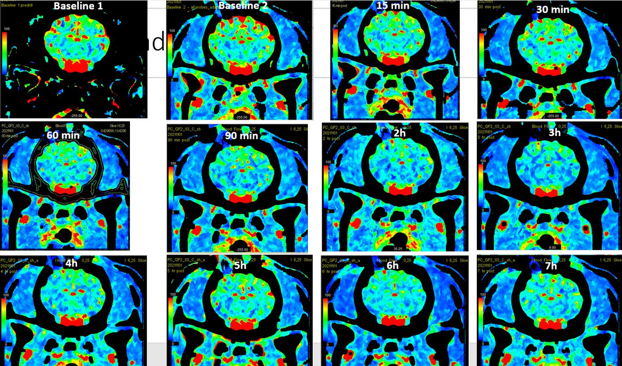

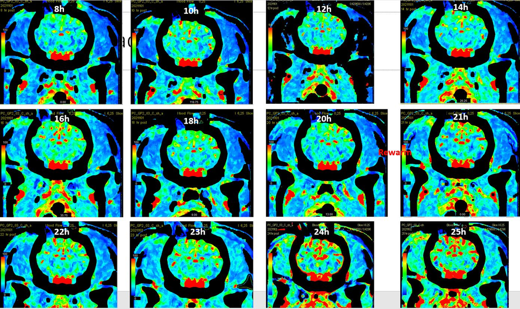

# Plots

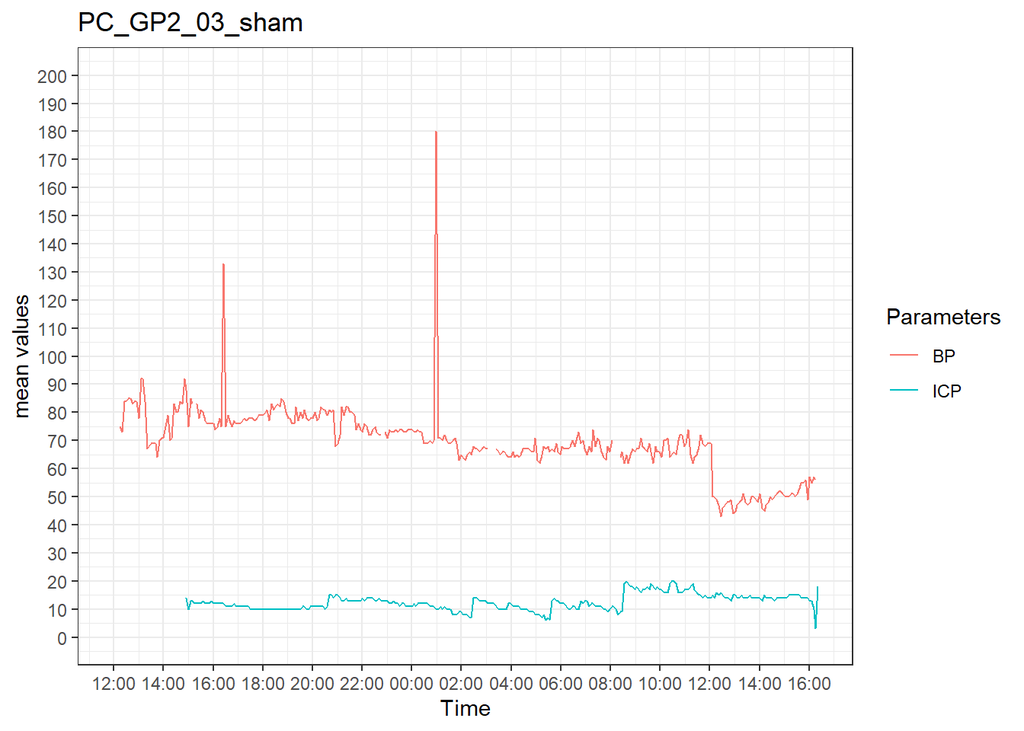

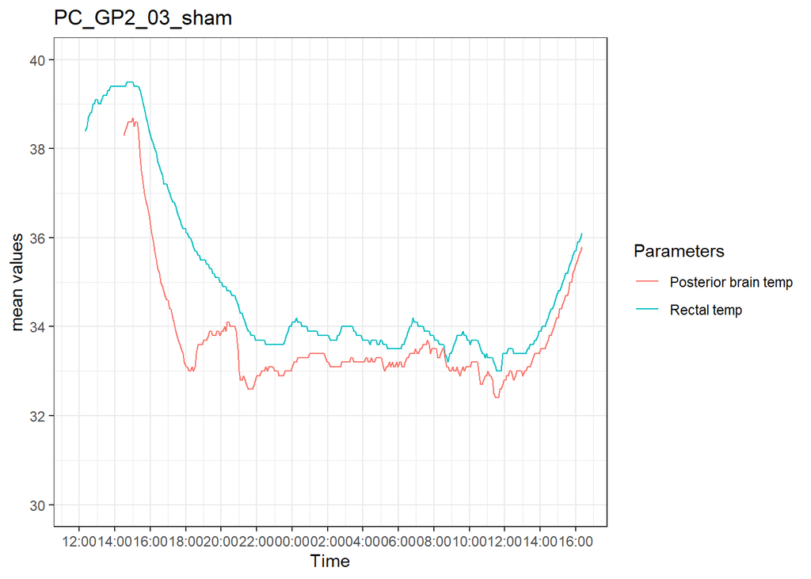

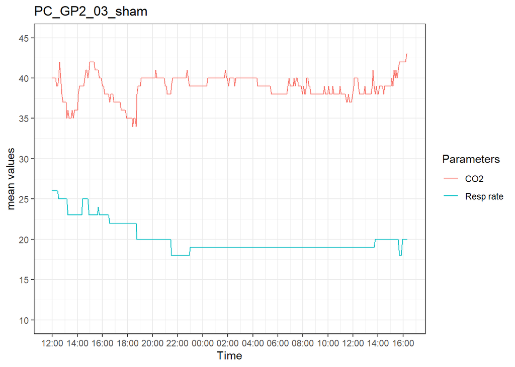

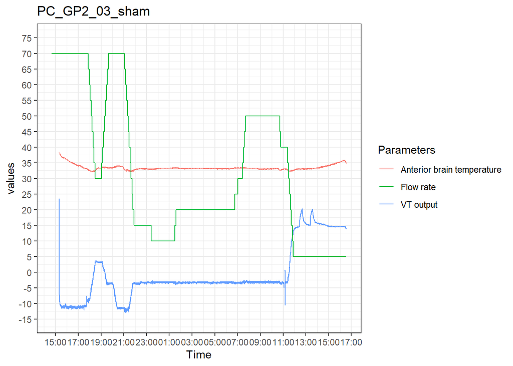

## TTC

No TTC result